# SPUTNIK DESI-MSI workflow

Paolo Inglese

2018-02-16

```r
library("SPUTNIK")
library("imager")
```

**IMPORTANT!** Do not normalize the peaks intensity matrix before running the `splitPeaksFilter`. Also the variance stabilizing transformation should be applied after the filter. The ovarian cancer DESI-MSI data set acquired with XEVO Q-TOF in negative ion mode has been pre-processed using [MALDIquant] (https://github.com/cran/MALDIquant) (Gibb and Strimmer 2012). **No filter was applied during the pre-processing.** The intensity matrix has been loaded with the variable name `desiData`. The number of pixels is equal to 73 x 118 (x, y). MALDIquant assigns a NA to empty peak signals, these should be converted into zeros before running the analysis.

```r
desiData <- ovarianDESIDoria2016()
```

```
## Loading the data in the R environment...
```

```r
desiData[is.na(desiData)] <- 0
```

Define the geometrical shape variable, `sz`.

```r
sz <- attr(desiData, "size")
```

```r
## Assign the NA values to 0 and print the dimensions of the intensity matrix
print(dim(desiData))
```

```
## [1] 8614 1375
```

```r
# Create the MSI dataset. MALDIquant assigns the matched m/z values to the
# columns name of the intensity matrix
msiX <- msiDataset(values = desiData,
                   mz = as.numeric(colnames(desiData)),
                   rsize = sz[1], csize = sz[2])
```

## Merge estimated split peaks

Firstly, we test whether some peaks have been split during the matching process. This can be due to issues with the spectra alignment. Usually, this error generates close peaks that are spatially localized in complementary regions. In the `splitPeaksFilter`, the smallest distance that defines close peaks is expressed in ppm. This value should be carefully chosen to be close to the instrumental error; a too large value will produce a wrong merging. The `sharedPixelsRatio` represents the maximum accepted ratio between the pixels shared by two or more peaks and the total number of peaks signal pixels.

Estimate the split peaks.

```r
split.peaks <- splitPeaksFilter(msiData = msiX,
                                mzTolerance = 10,
                                sharedPixelsRatio = 0,
                                sparseness = "scatter.ratio",
                                threshold = 0.5,
                                returnDetails = T,
                                verbose = T)
```

```
## Determining close peaks. This may take a while...
## Min. distance between peaks (ppm) = 31.12587
## No peak groups to merge found.
```

In this case, no groups of peaks have been merged, since the minimum distance between peaks is larger than the `mzTolerance` value.

Now we can normalize the intensities with median scaling and apply the log-transformation. This was skipped during `MALDIquant` pre-processing in order to have a correct normalization after the peaks merging. Let’s apply the transformations also to the original matrix for a subsequent comparison of the results.

```r
## Normalization and log-transformation of the original intensity matrix.
Start.time <- Sys.time()

## Apply median scaling without considering the zeros.
desiData[desiData == 0] <- NA

for (i in 1:nrow(desiData))
{
  desiData[i, ] <- desiData[i, ] /
    median(desiData[i, ], na.rm = T)
}

desiData[is.na(desiData)] <- 0

## Apply the log-transformation adding a constant equal to 1 in order to preserve
## the zeros
desiData <- log(desiData + 1)

Sys.time() - Start.time
```

```
## Time difference of 1.863266 secs
```

Normalize the msiX matrix elements.

```r
## Apply median scaling and log-transformation to the MSI dataset
start.time <- Sys.time()

msiX <- normIntensity(msiX, "median")
msiX <- varTransform(msiX, "log")

Sys.time() - start.time
```

```
## Time difference of 1.529579 secs
```

## Determine the reference image and the ROI

Before, extracting the reference image and the ROI, we to select the measure to be used to calculate the reference intensities among `sum`, `mean`, `median`, and `pca`. Furthermore, we have to provide the method used to generate the ROI, among `otsu` and `kmeans`.

```r
## Now apply Gaussian smoothing (standard deviation = 2, by default) to the
## reference image, before calculating the binary ROI mask with the Otsu's
## thresholding.

ref.roi <- refAndROIimages(msiData = msiX,
                           refMethod = "sum",
                           roiMethod = "otsu",
                           mzQueryRef = numeric(),
                           useFullMZRef = TRUE,
                           smoothRef = TRUE, # <== SMOOTHING
                           invertRef = FALSE,
                           verbose = TRUE)
```

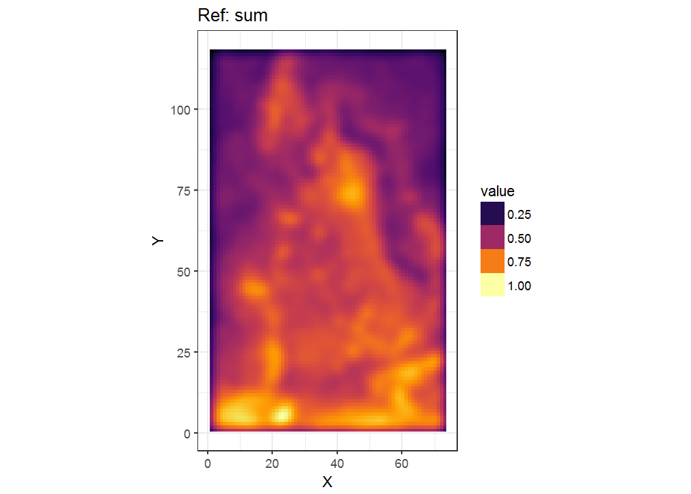

```r
## Visualize the reference image. Now it appears smoothed.
plot(ref.roi$Reference)
```

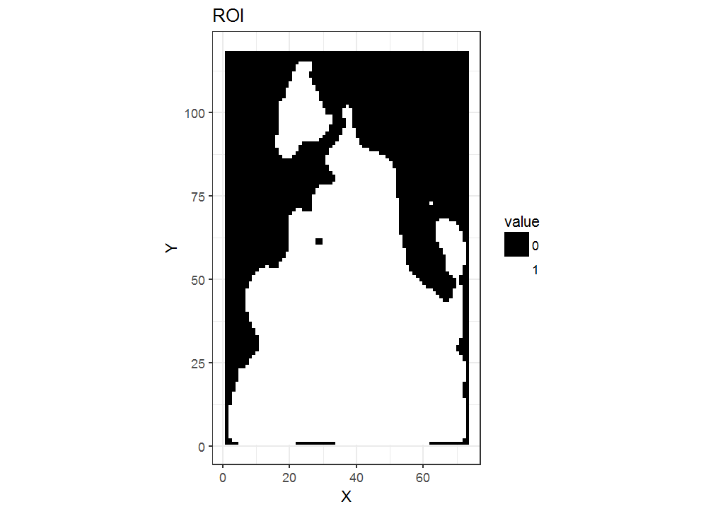

```r
## Visualize the binary ROI mask. The smoothing has reduces the pixelation of
## the binary mask.
plot(ref.roi$ROI)
```

It is important to select the best reference image and ROI mask parameters, since they will be used for the following filtering steps.

## Global similarity filter

```r
## globalPeaksFilter selects the peaks which intensities are similar more than
## "threshold" with the "referenceImage". In this case, the referenceImage is
## the smoothed sum of peaks intensities, calculated previously, the selected
## peaks have Pearson's correlation with it larger than 0. Also, the binary
## ROI mask can be used as referenceImage, but in that case it is suggested
## to use Spearman's correlation, SSIM or NMI.
start.time <- Sys.time()

sel.peaks <- globalPeaksFilter(msiData = msiX,
                               referenceImage = ref.roi$Reference,
                               method = "pearson",
                               threshold = 0,
                               verbose = TRUE)
```

```
## Calculating the similarity values...
```

```r
Sys.time() - start.time
```

```
## Time difference of 0.270472 secs
```

```r
## Apply the filter to the MSI dataset
msiX <- applyPeaksFilter(msiX, sel.peaks)
cat("new dimensions:", dim(getIntensityMat(msiX)), "\n")
```

```
## new dimensions: 8614 985
```

Generally, `globalPeaksFilter` reduces significantly the number of matched peaks and increases the contrast between the ROI and the region outside.

**Here, we update the reference image and ROI after applying the filter.**

```r
## Re-calculate the reference and ROI mask after applying the correlation based
## filter. After removing the peaks localized outside the region occupied by the
## tissue section, the reference and ROI become much clearer. Here we use the
## same parameters used previously.
ref.roi <- refAndROIimages(msiData = msiX,
                           refMethod = "sum",
                           roiMethod = "otsu",
                           useFullMZRef = TRUE,
                           smoothRef = FALSE,
                           invertRef = FALSE,
                           verbose = TRUE)
```

Compare the original and the filtered TIC images.

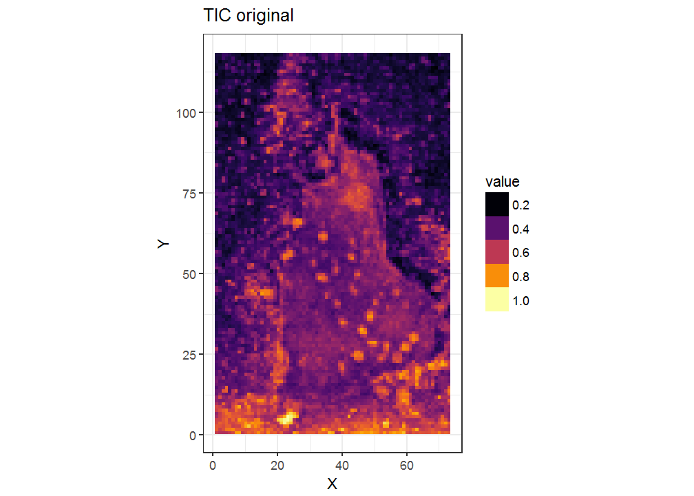

```r
## Visualize the sum of peaks intensities image from the original and filtered
## dataset.
par(mfrow = c(1, 2), mar = c(1, 0.2, 1, 0.2))
im <- apply(desiData, 1, sum)

plot(msImage(values = matrix(im, getShapeMSI(msiX)[1], getShapeMSI(msiX)[2]),
             name = "TIC original", scale = T))
```

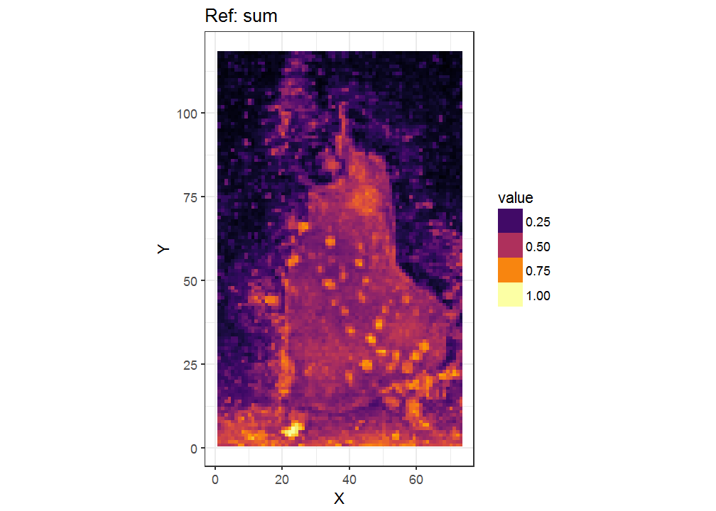

```r
plot(ref.roi$Reference)
```

## Connected pixels count based filter

`countPixelsFilter` is applied to remove peaks localized in small or scattered regions. This filter removes all the peaks which intensities are localized in connected regions smallest than `minNumPixels` within the ROI. Different aggressiveness levels determine whether also the connected components outside the ROI should be evaluated. Pixel size is equal to about 100um. Here, we are interested in all the sub-regions with an area larger than 90000um^2 Different levels of aggressiveness can produce different results.

We will set `aggressive` equal to 1.

```r
## Count filter selects the peaks with a signal localized in clusters of pixels
## of size larger than "minNumPixels". The signal pixels are extracted applying
## Otsu's thresholding to the peak intensity image. Here, we select peaks that
## are connected in regions larger than 9 pixels. This parameter depends on the
## size of expected realistic sub-regions, and it is closely connected with the
## physical pixel size.

start.time <- Sys.time()
res.count.filter <- countPixelsFilter(msiData = msiX,
                                      roiImage = ref.roi$ROI,
                                      minNumPixels = 9,
                                      aggressive = 1,
                                      verbose = FALSE)
Sys.time() - start.time
```

```
## Time difference of 8.582445 secs
```

```r
print(length(res.count.filter$sel.peaks))
```

```
## [1] 601
```

```r
## Apply the filter - the second element of the previosly calculated list
## corresponds to aggressive = 1
msiX <- applyPeaksFilter(msiX, res.count.filter)
```

## Complete spatial randomness filter

```r
## Here, we select the peaks for which the corresponding point pattern process
## (see spatstat::ppp for more details) hypothesis of complete spatial randomness
## can be rejected. In this case, we use the Clark Evans test, additional
## arguments, compatible with spatstat::clarkevans.test can be passed to the
## function. The p-values are corrected using Bonferroni correction.
res.csr.stats <- CSRPeaksFilter(msiData = msiX,
                                method = "ClarkEvans",
                                calculateCovariate = FALSE,
                                adjMethod = "bonferroni",
                                returnQvalues = TRUE,
                                plotCovariate = FALSE,
                                verbose = TRUE)
```

```
## Calculating the reference image. This may take a while...
## Scaling all the peaks intensities in [0, 1]
## Starting CSR tests. This may take a while...
## 500
```

```r
## Set a threshold of 0.001 for rejection of complete spatial randomness.
cat(sum(res.csr.stats$p.value < 0.001), "\n")
```

```
## 454
```

```r
cat(sum(res.csr.stats$q.value < 0.001), "\n")
```

```
## 398
```

Apply the filtering

```r
## Select the peaks for which the null hypothesis of complete spatial randomness
## can be rejected, using the Bonferroni corrected q-values.
csr.filt <- createPeaksFilter(which(res.csr.stats$q.value < 0.001))

msiX <- applyPeaksFilter(msiX, csr.filt)
```

## Comparison between the original and filtered datasets

Here we extract the first 3 principal components and visualize them as RGB channels. The scores are first scaled in [0, 1].

```r
## PCA original dataset
start.time <- Sys.time()
pca.orig <- prcomp(desiData)
Sys.time() - start.time
```

```
## Time difference of 45.42632 secs
```

```r
## PCA filtered dataset
start.time <- Sys.time()
pca.filt <- prcomp(getIntensityMat(msiX))
Sys.time() - start.time
```

```
## Time difference of 3.563724 secs
```

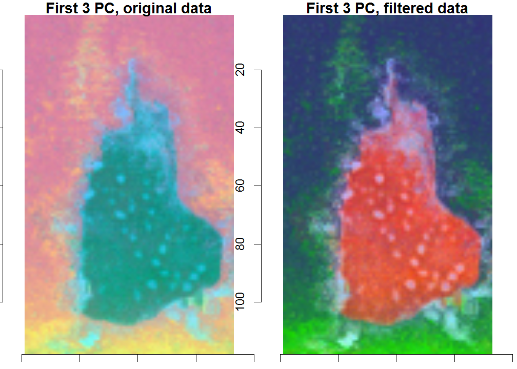

```r
## Plot the first 3 principal components as RGB channels
im.orig.rgb <- array(NA, c(sz[1], sz[2], 1, 3))
for (i in 1:3) {
  im.orig.rgb[, , 1, i] <- matrix(pca.orig$x[, i] / max(pca.orig$x[, i]),
                                  sz[1], sz[2])[, sz[2]:1]
}
im.filt.rgb <- array(NA, c(sz[1], sz[2], 1, 3))
for (i in 1:3) {
  im.filt.rgb[, , 1, i] <- matrix(pca.filt$x[, i] / max(pca.filt$x[, i]),
                                  sz[1], sz[2])[, sz[2]:1]
}
par(mfrow = c(1, 2), mar = c(1, 0.2, 1, 0.2))
plot(as.cimg(im.orig.rgb), main = "First 3 PC, original data")
plot(as.cimg(im.filt.rgb), main = "First 3 PC, filtered data")
```

Here we compare the clustering results using k-means with a number of clusters equal to 5 on the first K principal components scores responsible of the 95% of the total variance.

```r
## Determine the number of principal components responsible of the 95% of the
## total variance
var.perc.orig <- cumsum(pca.orig$sdev^2 / sum(pca.orig$sdev^2))
var.perc.filt <- cumsum(pca.filt$sdev^2 / sum(pca.filt$sdev^2))
num.comps.orig <- which(var.perc.orig >= 0.95)[1]
num.comps.filt <- which(var.perc.filt >= 0.95)[1]
cat("Num. components original dataset =", num.comps.orig, "\n")
```

```
## Num. components original dataset = 358
```

```r
cat("Num. components filtered dataset =", num.comps.filt, "\n")
```

```
## Num. components filtered dataset = 187
```

```r
start.time <- Sys.time()
clust.orig <- kmeans(pca.orig$x[, 1:num.comps.orig], centers = 5,
                     iter.max = 1000, nstart = 50)
Sys.time() - start.time
```

```
## Time difference of 20.25404 secs
```

```r
start.time <- Sys.time()
clust.filt <- kmeans(pca.filt$x[, 1:num.comps.filt], centers = 5,
                     iter.max = 1000, nstart = 50)
Sys.time() - start.time
```

```
## Time difference of 11.80567 secs
```

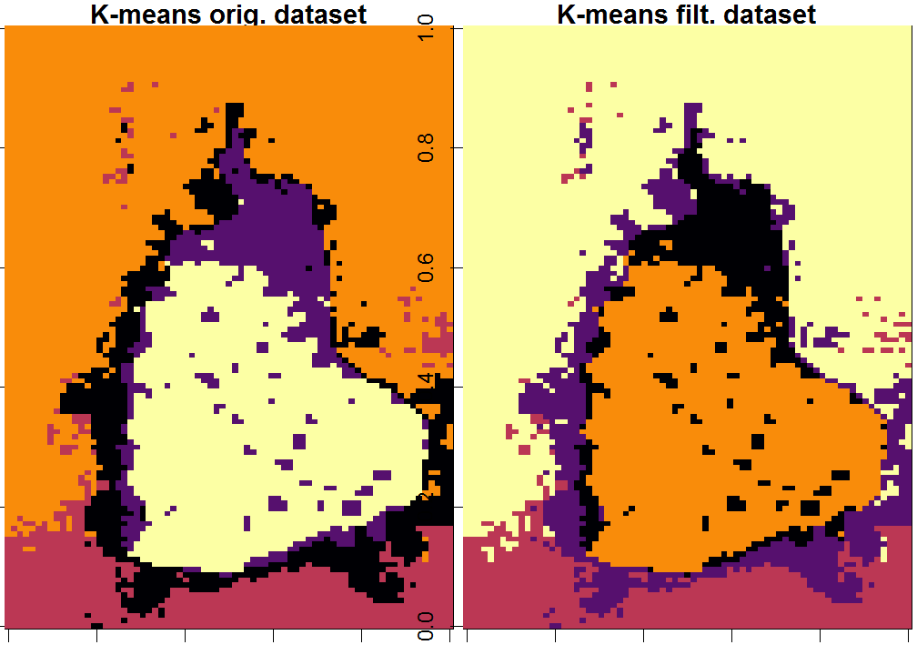

```r
## Visualize the clusters
par(mfrow = c(1, 2), mar = c(1, 0.2, 1, 0.2))
image(matrix(clust.orig$cluster, sz[1], sz[2]), col = viridis::inferno(5),
      main = "K-means orig. dataset")
image(matrix(clust.filt$cluster, sz[1], sz[2]), col = viridis::inferno(5),
      main = "K-means filt. dataset")
```

Finally, let’s check the image corresponding to the smallest number of signal pixels.

```r
## Calculate the fraction of signal pixels for each peak.
num.pixels <- nrow(getIntensityMat(msiX))
frac <- array(0, ncol(getIntensityMat(msiX)))
for (i in 1:length(frac))
{
  frac[i] <- sum(getIntensityMat(msiX)[, i] != 0) / num.pixels
}

## The smallest sub-region
print(min(frac))
```

```
## [1] 0.005688414
```

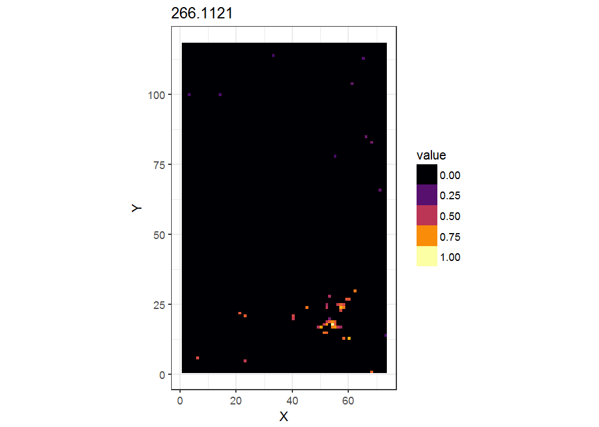

```r
## Visualize the peak image corresponding to the smallest sub-region
im.smallest <- matrix(getIntensityMat(msiX)[, which.min(frac)],
                      getShapeMSI(msiX)[1], getShapeMSI(msiX)[2])

plot(msImage(im.smallest,
             name = as.character(round(getMZ(msiX)[which.min(frac)], 4))
             )
     )
```

Clearly, this intensity image shows a non-random pattern that would have been removed by a naive fraction filter with a threshold of 1%.

## References

Gibb, Sebastian, and Korbinian Strimmer. 2012. “MALDIquant: A Versatile R Package for the Analysis of Mass Spectrometry Data.” *Bioinformatics* 28 (17). Oxford University Press: 2270–1.